# One and Two Proportions - Week 10, Lecture 1

Author

Hector Gavilanes

#### Load libraries

```r
library("tidyverse")
library("gsheet")
library("formattable")
```

**1. Consider the Jackson Heart Study dataset.**

```r
# clear environment
rm(list = ls())
# import data
data <- as_tibble(gsheet2tbl("https://docs.google.com/spreadsheets/d/1H3TP-2SBMGleriJLESOe1cdCjtSj2F76bUh5iBqC8tI/edit#gid=2142000894"))
```

**1a. Find the 95% CI for the proportion of JHS participants that drink alcohol on a regular basis (alc; 1=yes, 0=no).**

```r
# alcohol count
formattable(data) %>%
  count(alc)
```

| alc | n |
| --- | --- |
| No | 1372 |
| Yes | 1271 |
| NA | 10 |

```r
# get Confidence Intervals
alcohol_ci <- prop.test(x = 1271,
                        n = 1372+1271,
                        correct=FALSE)
round(alcohol_ci$conf.int, digits = 3)
```

```
[1] 0.462 0.500
attr(,"conf.level")
[1] 0.95
```

- The 95% CI for $\pi$, the population proportion of JHS participants that drink alcohol on a regular basis is (0.462, 0.500)

```r
# n = 2643
# yes = 1271
# no = 1372

# drinkers < 50%
alcohol_proportion <- prop.test(x = 1271,
                                n = 1372+1271,
                                p = 0.50,
                                alternative = "less",
                                correct=FALSE)
alcohol_proportion
```

```
    1-sample proportions test without continuity correction

data:  1271 out of 1372 + 1271, null probability 0.5
X-squared = 3.8596, df = 1, p-value = 0.02473
alternative hypothesis: true p is less than 0.5
95 percent confidence interval:
 0.00000 0.49689
sample estimates:
        p
0.4808929
```

```r
# get X-squared
x_squared <- alcohol_proportion$statistic
# get Z0
z0 = round(sqrt(alcohol_proportion$statistic), digits = 3)
```

### Hypothesis Test: Alcohol Drinkers

### Hypotheses

- $H_0: \pi_{alcohol} \ge 0.50$
- $H_1: \pi_{alcohol} < 0.50$

### Test Statistic and p-Value

- $X^2_{0}$ = 3.8596292 or $z_0$ = $\sqrt{3.8596}$ = 1.965

## Conclusion

Reject $H_0$ at $\alpha = 0.05$. There is sufficient evidence to suggest that less than 50% of the JHS participants drink alcohol on a regular basis.

**1c. Find the 99% CI for the difference in the proportion of male and female JHS participants that drink alcohol.**

```r
# get matrix/table
table(data$alc, data$sex)
```

```
      Female Male
  No     982  390
  Yes    684  587
```

```r
# n female = 1666
982+684
```

```
[1] 1666
```

```r
684/1666
```

```
[1] 0.4105642
```

```r
# n male = 977
390+587
```

```
[1] 977
```

```r
587/977
```

```
[1] 0.6008188
```

```r
# 99% CI for two proportions
gender_proportion <- prop.test(x = c(684, 587),
                               n = c(1666, 977),
                               correct = FALSE,
                               conf.level = 0.99)
# get CI
gender_proportion
```

```
    2-sample test for equality of proportions without continuity correction

data:  c(684, 587) out of c(1666, 977)
X-squared = 89.297, df = 1, p-value < 2.2e-16
alternative hypothesis: two.sided
99 percent confidence interval:
 -0.2411714 -0.1393378
sample estimates:
   prop 1    prop 2
0.4105642 0.6008188
```

```r
gender_ci <- round(gender_proportion$conf.int, digits = 3)
```

- The 99% CI for $\pi_F$ - $\pi_M$ is (-0.241, -0.139).
- Because the interval is negative, it indicates that the proportion of JHS participants in the female group is smaller than the male group.

```r
# count hypertension
data %>%
  count(data$alc)
```

```
# A tibble: 3 × 2
  `data$alc`     n
  <chr>      <int>
1 No          1372
2 Yes         1271
3 <NA>          10
```

```r
# drinkers with hypertension count
table(data$HTN, data$alc)
```

```
       No Yes
  No  547 683
  Yes 825 588
```

```r
# drinkers n = 1271
# drinkers+HTN = 588
# drinkers-HTN = 683

htn_proportion <- prop.test(x = c(588, 683),
                            n = c(1271, 1271),
                            alternative = "less",
                            correct = FALSE)
htn_proportion
```

```
    2-sample test for equality of proportions without continuity correction

data:  c(588, 683) out of c(1271, 1271)
X-squared = 14.201, df = 1, p-value = 8.212e-05
alternative hypothesis: less
95 percent confidence interval:
 -1.00000000 -0.04221138
sample estimates:
   prop 1    prop 2
0.4626279 0.5373721
```

```r
# get X-squared
x_squared_htn <- htn_proportion$statistic
# get Z0
z_htn = round(sqrt(x_squared_htn), digits = 3)
```

### Hypothesis Test: Alcohol Drinkers

- The proportion of drinkers with hypertension,

### Hypotheses

- $H_0: \pi_{drinkers+HTN} \ge \pi_{drinker}$
- $H_1: \pi_{drinkers+HTN} < \pi_{drinker}$

### p-Value

- $p < 0.001$

## Conclusion

Reject $H_0$ at $\alpha = 0.05$. There is sufficient evidence to suggest that there are fewer drinkers with hypertension than those without hypertension.

**1e. Challenge! Construct a graph to help with explanation to the lead scientist of JHS.**

##### Regular Drinkers

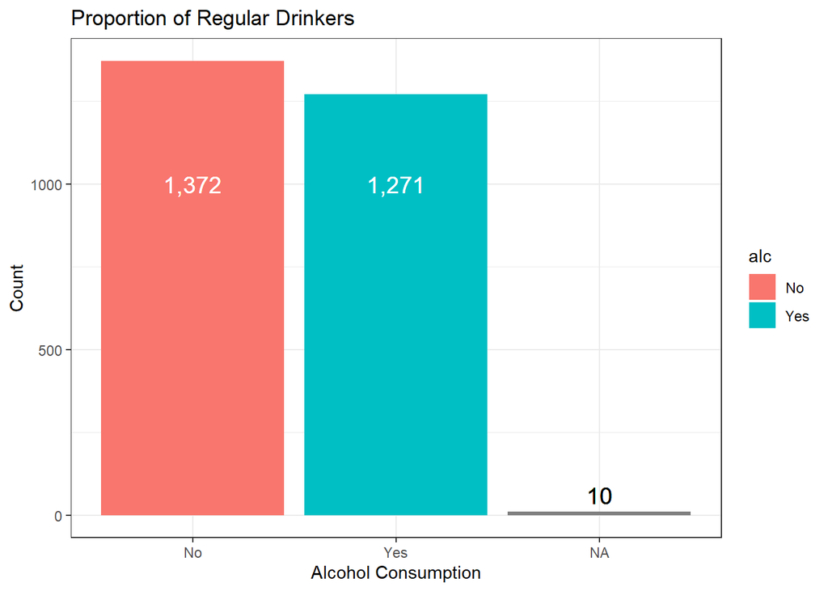

```r
# grouped barchart
alcohol_count <- data %>%
  count(alc)

ggplot(alcohol_count, aes(fill = alc, y = n, x = alc))+
  geom_col()+
  scale_fill_discrete(breaks = c("No", "Yes", "NA"))+
  labs(title = "Proportion of Regular Drinkers",
       x = "Alcohol Consumption",
       y = "Count")+
  theme_bw()+
  geom_text(label = "1,372",x = 1, y = 1000, size = 5, colour = "white")+
  geom_text(label = "1,271",x = 2, y = 1000, size = 5, colour = "white")+
  geom_text(label = "10",x = 3, y = 60, size = 5, colour = "black")
```

##### Drinkers by Gender

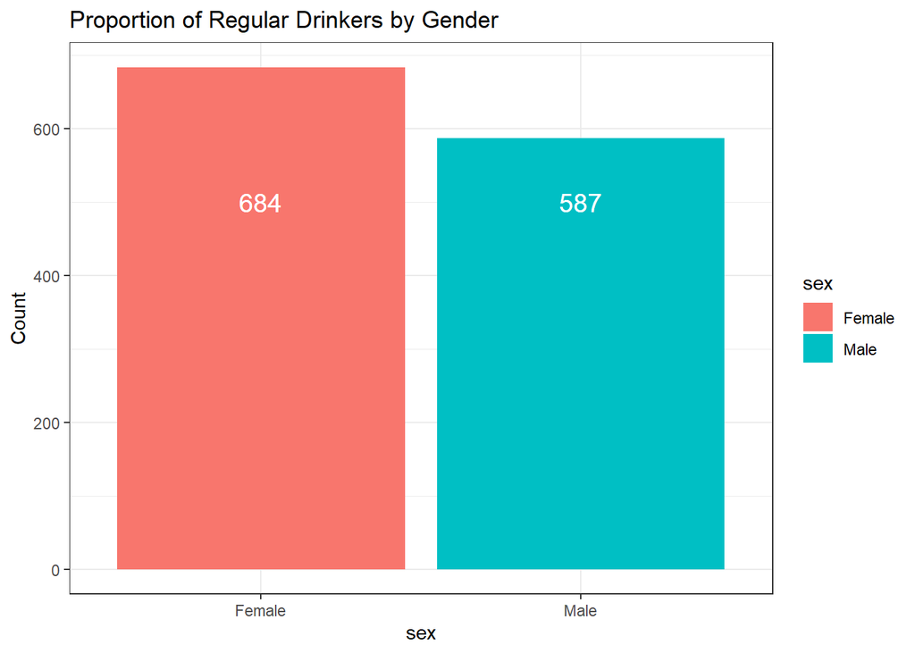

```r
# get drinkers sex
gender_drinkers <- data %>%
  select(sex, alc) %>%
  filter(alc == "Yes") %>%
  count(sex)

# grouped barchart
ggplot(gender_drinkers, aes(fill = sex, y = n, x = sex))+
  geom_col()+
  scale_fill_discrete(breaks = c("Female", "Male"))+
  labs(title = "Proportion of Regular Drinkers by Gender",
       y = "Count")+
  theme_bw()+
  geom_text(label = "684",x = 1, y = 500, size = 5, colour = "white")+
  geom_text(label = "587",x = 2, y = 500, size = 5, colour = "white")
```

##### Drinkers with Hypertension

```r
# drinkers with hypertension count
table(data$HTN, data$alc)
```

```
       No Yes
  No  547 683
  Yes 825 588
```

```r
# get drinkers with hypertension
htn_drinkers <- data %>%
  select(HTN, alc) %>%
  filter(alc == "Yes") %>%
  count(HTN)
htn_drinkers
```

```
# A tibble: 2 × 2
  HTN       n
  <chr> <int>
1 No      683
2 Yes     588
```

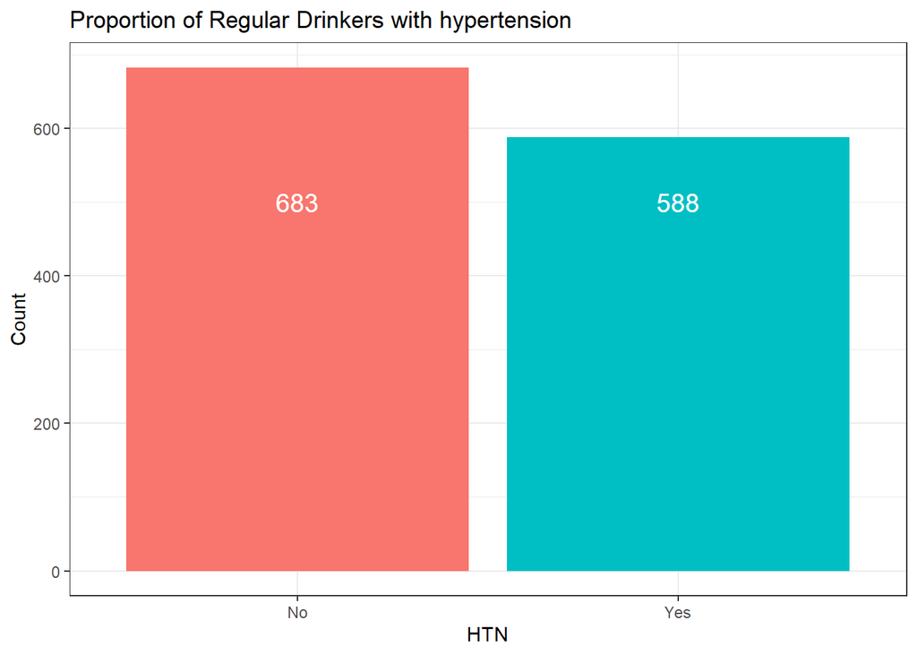

```r
# grouped barchart
ggplot(htn_drinkers, aes(fill = HTN, y = n, x = HTN))+
  geom_col()+
  scale_fill_discrete(breaks = c("HTN", "No-HTN"))+
  labs(title = "Proportion of Regular Drinkers with hypertension",
       y = "Count")+
  theme_bw()+
  geom_text(label = "683",x = 1, y = 500, size = 5, colour = "white")+
  geom_text(label = "588",x = 2, y = 500, size = 5, colour = "white")
```

**2. A large retail lawn care dealer currently provides a 2-year warranty on all lawn mowers sold at its stores. A new employee suggested that the dealer could save money by just not offering the warranty. To evaluate this suggestion, the dealer randomly decides whether or not to offer the warranty to the next 50 customers who enter the store and express an interest in purchasing a lawnmower. Out of the 25 customers offered the warranty, 10 purchased a mower as compared to 4 of 25 not offered the warranty.**

**2a. Find a 95% CI for the difference in the proportions of customers purchasing lawnmowers with and without the warranty.**

```r
# warranty proportion test
warranty_binom <- binom.test(x = c(4, 10),
                             n = c(25, 25))
warranty_binom
```

```
    Exact binomial test

data:  c(4, 10)
number of successes = 4, number of trials = 14, p-value = 0.1796
alternative hypothesis: true probability of success is not equal to 0.5
95 percent confidence interval:
 0.08388932 0.58103526
sample estimates:
probability of success
             0.2857143
```

```r
# get CI
warranty_ci <- round(warranty_binom$conf.int, digits = 3)
warranty_ci
```

```
[1] 0.084 0.581
attr(,"conf.level")
[1] 0.95
```

**2b. What are the requirements for using the z distribution when analyzing proportions?**

- The sample size should be greater than 30.
- Test results are accurate when $n\pi$ and $n(1-\pi)$ are greater than 5.
- Both populations follow a binomial distribution.

**2c. Check those requirements here.**

The sample was collected among 50 customers; however, the marginal total, or sample size for both groups is 25.

Therefore, we cannot use the Z-distribution.

**2d. Is the CI in part 2a valid? Why or why not?**